# R Notebook

## B) Solution:

```r
library(data.table)
```

```r
# Marginal distribution of country
df = as.data.frame(transpose(tail(data[,2:8], n=1)))
colnames(df) <- c("Total")
df$country <- colnames(data[,2:8])
df
```

| Total | country |
| --- | --- |
| 176 | Canada |
| 672 | France |
| 218 | Germany |
| 321 | Italy |
| 645 | Japan |
| 475 | UK |
| 2069 | US |

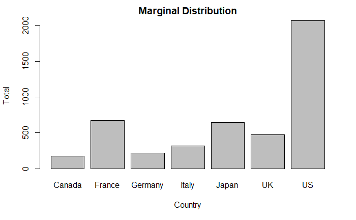

```r
barplot(df$Total,names.arg = df$country, main="Marginal Distribution", xlab="Country", ylab = "Total")
```

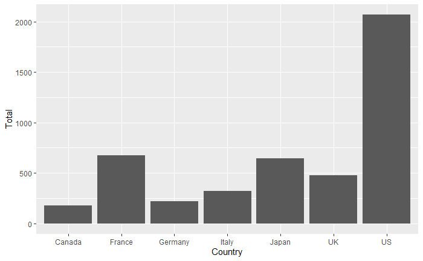

```r
ggplot(df, aes(x=country, y=Total)) + geom_bar(stat="identity") +
  labs(x="Country", y="Total")
```

## C) Solution:

```r
df2 = data[ , ncol(data), drop = FALSE]
df2$field = data$Field
df2
```

| total | field |
| --- | --- |
| 1688 | SsBL |
| 911 | SME |
| 801 | AH |
| 319 | Ed |
| 857 | Other |
| 4576 | Total |

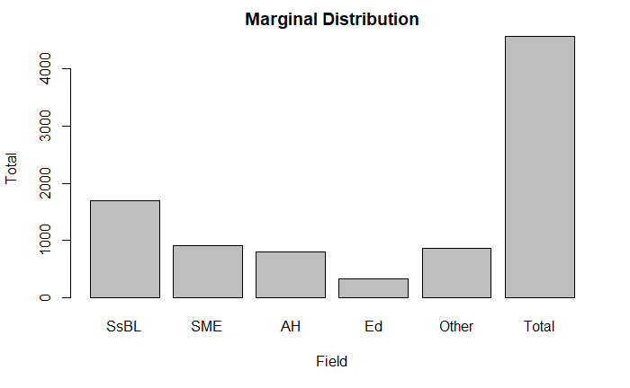

```r
barplot(df2$total,names.arg = df2$field, main="Marginal Distribution", xlab="Field", ylab = "Total")
```

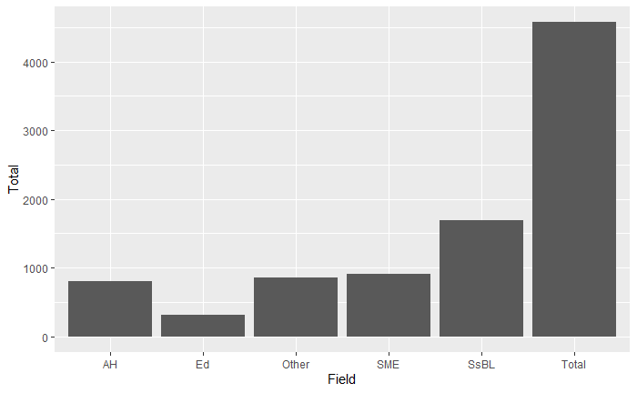

```r
ggplot(df2, aes(x=field, y=total)) + geom_bar(stat="identity") +
  labs(x="Field", y="Total")
```

# Problem 2.162

### Read xls file

```r
file_name = "ex02-162raises.xls"
data = read_xls(file_name)
```

### Preview tibble

```r
data
```

| Year | Salary |
| --- | --- |
| 1 | 50 |
| 2 | 53 |
| 3 | 56 |
| 4 | 58 |
| 5 | 61 |
| 6 | 63 |
| 7 | 67 |
| 8 | 70 |
| 9 | 74 |
| 10 | 78 |

[output cut: 10 more lines]

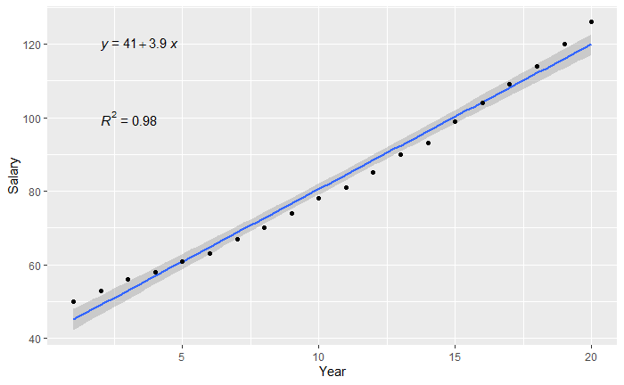

```r
ggplot(data=data, aes(x=Year, y=Salary)) +
        geom_smooth(method="lm") +
        geom_point() +
        stat_regline_equation(label.x=2, label.y=120) +
        stat_cor(aes(label=..rr.label..), label.x=2, label.y=100)
```

## A) Solution:

*From the graph we can see that there is a strong positive association between salary and year.*

## B) Solution:

```r
rsq <-  round(cor(data$Year, data$Salary) ^ 2,4)
rsq
```

```
[1] 0.9832
```

*As the R2 value is 0.9832, 98.32% of variation in salary is explained by the year*

# Problem 2.162

## A) Solution:

```r
data.lm = lm(Salary ~ Year, data=data)
data.res = resid(data.lm)
```

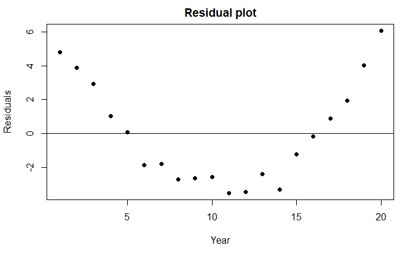

```r
plot(data$Year, data.res, ylab="Residuals", xlab="Year", main="Residual plot", pch=19)
abline(0, 0)
```

```r
mean(data.res)
```

```
[1] 1.000502e-16
```

*In the graph above, we can see that the residual values are not randomly distributed around the horizon (y=0)(which should have been the case had the data been perfectly linear) but follow a pattern. This happened due to inconsistent percentage of raise (<=5%). But the mean of deviations is pretty close to zero.*

## B) Solution:

*This residual plot indicates that the independent variable (year) does not capture the entire deterministic component. Unfortunately, some of the explanatory data has leaked over to the supposedly random error. The model obviously has room for improvement.*

# Problem 2.166

### Read xls file

```r
file_name = "ex02-166faculty.xls"
data = read_xls(file_name)
```

### Preview tibble

```r
data
```

| Salary2012 | Salary2013 |
| --- | --- |
| 146600 | 147700 |
| 115800 | 118600 |
| 112000 | 115500 |
| 101700 | 105800 |
| 115000 | 117180 |
| 114790 | 117240 |
| 106500 | 111100 |
| 152000 | 156080 |
| 139650 | 142350 |
| 135160 | 138485 |

[output cut: 6 more lines]

## A) Solution:

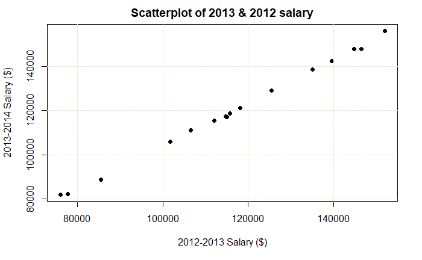

```r
# Scatterplot of 2013 & 2021 salary
plot(data$Salary2012, data$Salary2013, main="Scatterplot of 2013 & 2012 salary",
   xlab="2012-2013 Salary ($)", ylab="2013-2014 Salary ($)", pch=19)
grid (NULL,NULL, lty = 6, col = "cornsilk2")
```

## B) Solution:

*The relationship is linear in nature. It is showing an increasing trend. As the 2012-2013 Salary increases, so does the 2013-2014 Salary. There seems to be a very strong positive association between the two variables.*

## B) Solution:

```r
rsq <-  cor(data$Salary2012, data$Salary2013) ^ 2
rsq
```

```
[1] 0.9984137
```

*So 99.84% of the variance of 2013-2014 Salary can be explained by 2012-2013 Salary.*

# Problem 2.177

### Read xls file

```r
file_name = "ex02-177csize.xls"
data = read_xls(file_name)
```

### Preview tibble

```r
data
```

| Department | Year | Size | Count |
| --- | --- | --- | --- |
| A | First | Large | 2 |
| A | First | Small | 0 |
| A | Second | Large | 9 |
| A | Second | Small | 1 |
| A | Third | Large | 5 |
| A | Third | Small | 15 |
| A | Fourth | Large | 4 |
| A | Fourth | Small | 16 |
| B | First | Large | 18 |
| B | First | Small | 2 |

[output cut: 6 more lines]

```r
colnames(data)
```

```
[1] "Department" "Year"       "Size"       "Count"
```

```r
# Total number of classes in department A
a_tot = sum(data[data$Department=="A",]["Count"])
print(paste("Total number of classes in department A =",a_tot))
```

```
[1] "Total number of classes in department A = 52"
```

```r
# Total number of small classes in department A
a_s_tot = sum(data[data$Size=='Small' & data$Department=="A",]["Count"])
print(paste("Total number of small classes in department A =",a_s_tot))
```

```
[1] "Total number of small classes in department A = 32"
```

```r
#The percentage of small classes in Department A
print(paste("The percentage of small classes in department A is", round(a_s_tot/a_tot*100,2), "%"))
```

```
[1] "The percentage of small classes in department A is 61.54 %"
```

```r
# Total number of classes in department B
b_tot = sum(data[data$Department=="B",]["Count"])
print(paste("Total number of classes in department B =",b_tot))
```

```
[1] "Total number of classes in department B = 106"
```

```r
# Total number of small classes in department B
b_s_tot = sum(data[data$Size=='Small' & data$Department=="B",]["Count"])
print(paste("Total number of small classes in department B =",b_s_tot))
```

```
[1] "Total number of small classes in department B = 42"
```

```r
#The percentage of small classes in Department B
print(paste("The percentage of small classes in department B is", round(b_s_tot/b_tot*100,2), "%"))
```

```
[1] "The percentage of small classes in department B is 39.62 %"
```

*It seems that department A has a higher % of small classes.*

```r
library(dplyr)
data = data %>% mutate(row = row_number())
data
```

| Department | Year | Size | Count | row |
| --- | --- | --- | --- | --- |
| A | First | Large | 2 | 1 |
| A | First | Small | 0 | 2 |
| A | Second | Large | 9 | 3 |
| A | Second | Small | 1 | 4 |
| A | Third | Large | 5 | 5 |
| A | Third | Small | 15 | 6 |
| A | Fourth | Large | 4 | 7 |
| A | Fourth | Small | 16 | 8 |
| B | First | Large | 18 | 9 |
| B | First | Small | 2 | 10 |

[output cut: 6 more lines]

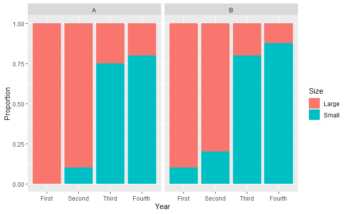

```r
ggplot(data=data, aes(x=reorder(Year,row), y=Count, fill=Size)) +
geom_bar(stat="identity", position = position_fill()) + xlab("Year") +
        ylab("Proportion") + facet_wrap(~Department)
```

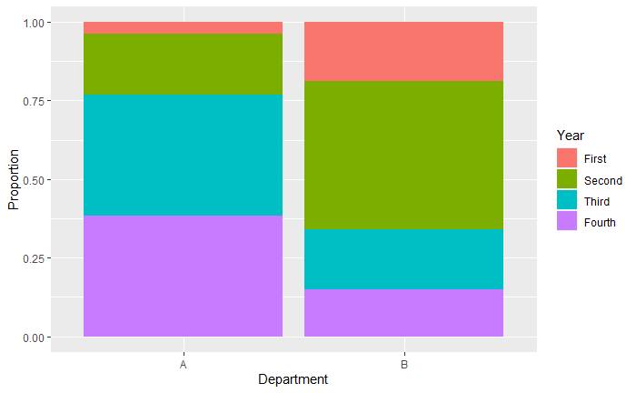

```r
ggplot(data=data, aes(x=Department, y=Count, fill=reorder(Year,row))) +
geom_bar(stat="identity", position = position_fill()) +
ylab("Proportion") + scale_fill_discrete(name = "Year")
```

*So, Department A has large proportion of third and fourth years classes.*

*Finally, we can test if there is an statistical association between years and size of the class, controlling by department. In other words, if the counts of large and small classes are statistically different between years, inside each department. This is done by analyzing this data as a contingency table. The test that evaluates association between two factors (Size and Year in this case), controlling for a third factor (department in this case) is the Mantel-Haenzel test. As in a chi-squared statistics, this evaluates deviations between observed and expected frequencies.*

*The hypothesis tested are:*

*H0 (null): There is not an association between year and size*

*H1 (alternative): There is an association between year and size*

*As in classical hypothesis testing, a p-value for the value of the statistic obtained in computed. The p-value is the probability of finding a value of the statistic equal or higher than the one obtained. The decision about which hypothesis the data supports is made based on a cutoff (alpha, level of significance, usually = 0.05). If p-value is smaller than alpha we reject the null hypothesis, if p-value is higher than alpha we do not reject the null hypothesis.*

```r
CT_data <- xtabs(data$Count~data$Size+data$Year+data$Department)

mantelhaen.test(CT_data)
```

```
    Cochran-Mantel-Haenszel test

data:  CT_data
Cochran-Mantel-Haenszel M^2 = 62.344, df = 3, p-value = 1.855e-13
```

*So, the p-value is below 0.05. We can reject the null hypothesis. So there are statistical differences in the proportions of small and large classes between years within each department. As we saw in the first figure, larger counts are associated with years third and fourth, and these differences are significant, and the differences of small classes proportion between two departments is due to the fact that department A has higher proportions of third and fourth classes (as shown in second figure)*